# Homework 5

**Due: 2022-3-3, 10:30am (before the class)**

We will use the [palmerpenguins](https://cran.r-project.org/web/packages/palmerpenguins/readme/README.html), which were collected and made available by Dr. Kristen Gorman and the Palmer Station, Antarctica LTER, a member of the Long Term Ecological Research Network.

The dataset contains data for 344 penguins of 3 different species (Adelie, Chinstrap and Gentoo). The dataset contains 8 variables, but we focus only on the flipper length and the species.

You can use the following commands to load penguins data in R, and check the information of dataset.

```r
# install.packages("palmerpenguins")
library(palmerpenguins)
data(penguins, package="palmerpenguins")
attach(penguins)
head(penguins)
```

```
## # A tibble: 6 x 8
##   species island bill_length_mm bill_depth_mm flipper_length_~ body_mass_g sex
##   <fct>   <fct>           <dbl>         <dbl>            <int>       <int> <fct>
## 1 Adelie  Torge~           39.1          18.7              181        3750 male
## 2 Adelie  Torge~           39.5          17.4              186        3800 fema~
## 3 Adelie  Torge~           40.3          18                195        3250 fema~
## 4 Adelie  Torge~           NA            NA                 NA          NA <NA>
## 5 Adelie  Torge~           36.7          19.3              193        3450 fema~
## 6 Adelie  Torge~           39.3          20.6              190        3650 male
## # ... with 1 more variable: year <int>
```

```r
table(penguins$species)
```

```
##
##    Adelie Chinstrap    Gentoo
##       152        68       124
```

You can use the the following commands to roughly check the flipper length for different species.

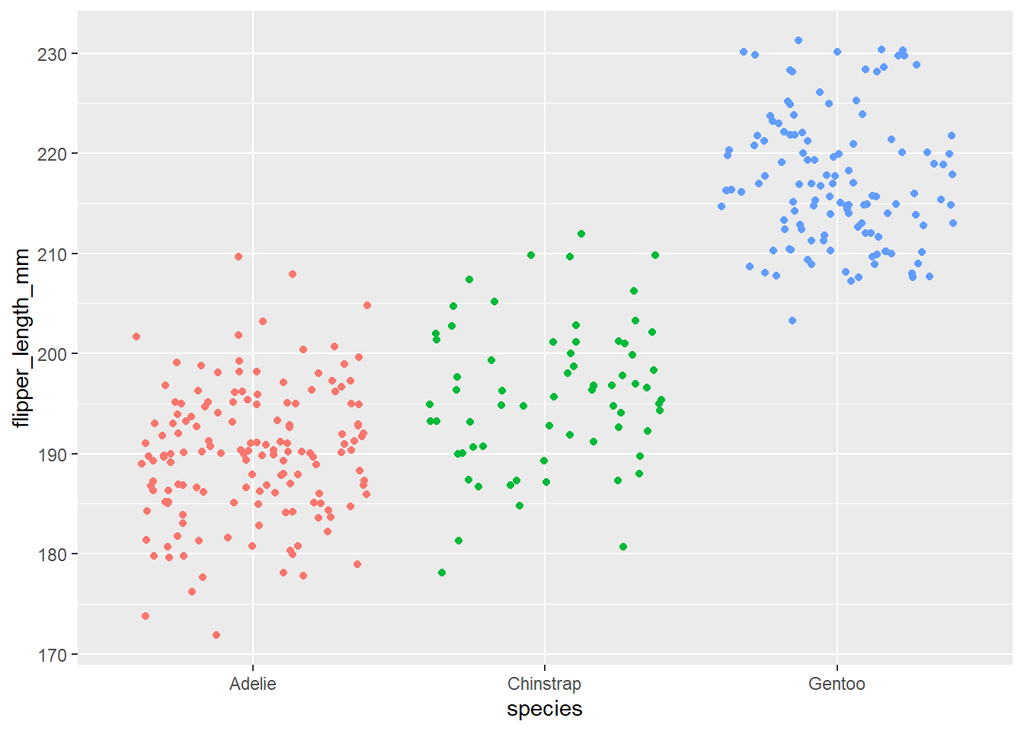

```r
library(ggplot2)
ggplot(penguins) +
  aes(x = species, y = flipper_length_mm, color = species) +
  geom_jitter() +
  theme(legend.position = "none")
```

### One-Way ANOVA

We are interested in the mean differences between species of flipper length.

1. (10%) Please calculate the mean and standard deviation of `flipper_length_mm` for each `species`.

```r
aggregate(flipper_length_mm, by=list(species), FUN=mean,na.rm=T)
```

```
##     Group.1        x
## 1    Adelie 189.9536
## 2 Chinstrap 195.8235
## 3    Gentoo 217.1870
```

```r
aggregate(flipper_length_mm, by=list(species), FUN=sd,na.rm=T)
```

```
##     Group.1        x
## 1    Adelie 6.539457
## 2 Chinstrap 7.131894
## 3    Gentoo 6.484976
```

2. (20%) Please apply one-way ANOVA to test the mean differences between species of flipper length and interpret the output.

```r
fit.anova <- aov(flipper_length_mm ~ species)
summary(fit.anova)
```

```
##              Df Sum Sq Mean Sq F value Pr(>F)
## species       2  52473   26237   594.8 <2e-16 ***
## Residuals   339  14953      44
## ---
## Signif. codes:  0 '***' 0.001 '**' 0.01 '*' 0.05 '.' 0.1 ' ' 1
## 2 observations deleted due to missingness
```

Output Interpretation: The means between species of flipper length are significantly different.

3. (10%) Use the `TukeyHSD()` function to obtain all pairwise differences between species means and interpret the output.

```r
TukeyHSD(fit.anova)
```

```
##   Tukey multiple comparisons of means
##     95% family-wise confidence level
##
## Fit: aov(formula = flipper_length_mm ~ species)
##
## $species
##                       diff       lwr       upr p adj
## Chinstrap-Adelie  5.869887  3.586583  8.153191     0
## Gentoo-Adelie    27.233349 25.334376 29.132323     0
## Gentoo-Chinstrap 21.363462 19.000841 23.726084     0
```

Output Interpretation:

- The mean flipper length between `Chinstrap` and `Adelie` are significantly different;
- The mean flipper length between `Gentoo` and `Adelie` are significantly different;
- The mean flipper length between `Gentoo` and `Chinstrap` are significantly different.
4. (10%)Try to use regression analysis to test the association between species and flipper length.

```r
fit.lm <- lm(flipper_length_mm ~ species)
summary(fit.lm)
```

```
##
## Call:
## lm(formula = flipper_length_mm ~ species)
##
## Residuals:
##      Min       1Q   Median       3Q      Max
## -17.9536  -4.8235   0.0464   4.8130  20.0464
##
## Coefficients:
##                  Estimate Std. Error t value Pr(>|t|)
## (Intercept)      189.9536     0.5405 351.454  < 2e-16 ***
## speciesChinstrap   5.8699     0.9699   6.052 3.79e-09 ***
## speciesGentoo     27.2333     0.8067  33.760  < 2e-16 ***
## ---
## Signif. codes:  0 '***' 0.001 '**' 0.01 '*' 0.05 '.' 0.1 ' ' 1
##
## Residual standard error: 6.642 on 339 degrees of freedom
##   (2 observations deleted due to missingness)
## Multiple R-squared:  0.7782, Adjusted R-squared:  0.7769
## F-statistic: 594.8 on 2 and 339 DF,  p-value: < 2.2e-16
```

### One-Way ANCOVA

We want to know whether or not the species has an association with flipper length accounting for the body mass.

The flipper length (`flipper_length_mm`) is the dependent variable. The species (`species`) is the independent variable. The body mass (`body_mass_g`) is included as a covariate.

5. (20%) Please apply one-way ANCOVA to test the mean differences between species of flipper length with controlling for the body mass.

```r
fit.ancova <- aov(flipper_length_mm ~ body_mass_g+species)
summary(fit.ancova)
```

```
##              Df Sum Sq Mean Sq F value Pr(>F)
## body_mass_g   1  51176   51176  1758.0 <2e-16 ***
## species       2   6411    3206   110.1 <2e-16 ***
## Residuals   338   9839      29
## ---
## Signif. codes:  0 '***' 0.001 '**' 0.01 '*' 0.05 '.' 0.1 ' ' 1
## 2 observations deleted due to missingness
```

6. (15%) Please interpret the output of Question 5.

The ANCOVA F tests indicate that (a) Body mass was related to flipper length (b) Species was related to flipper length after controlling for body mass.

7. (15%) Please use regression analysis to test the association between species and flipper length including the body mass as a covariate.

```r
fit.lm1 <- lm(flipper_length_mm ~ body_mass_g+species)
summary(fit.lm1)
```

```
##
## Call:
## lm(formula = flipper_length_mm ~ body_mass_g + species)
##
## Residuals:
##      Min       1Q   Median       3Q      Max
## -14.5455  -3.1845   0.1307   3.3533  17.5313
##
## Coefficients:
##                   Estimate Std. Error t value Pr(>|t|)
## (Intercept)      1.589e+02  2.387e+00  66.564  < 2e-16 ***
## body_mass_g      8.402e-03  6.339e-04  13.255  < 2e-16 ***
## speciesChinstrap 5.597e+00  7.882e-01   7.101 7.33e-12 ***
## speciesGentoo    1.568e+01  1.091e+00  14.374  < 2e-16 ***
## ---
## Signif. codes:  0 '***' 0.001 '**' 0.01 '*' 0.05 '.' 0.1 ' ' 1
##
## Residual standard error: 5.395 on 338 degrees of freedom
##   (2 observations deleted due to missingness)
## Multiple R-squared:  0.8541, Adjusted R-squared:  0.8528
## F-statistic: 659.4 on 3 and 338 DF,  p-value: < 2.2e-16
```